# PruebaFilogenetica

Diego Enrique Vargas Ramirez, Luis fernando Cuevas Arroyo

2023-05-03

# Análisis de 20 secuencias de ADN de los países más infectados

```r
setwd("C:/Users/UserOne/OneDrive/TEC - S2/BiologiaCompu/CodigoR/20_secuencias_2")

if (!require("BiocManager", quietly = TRUE))
    install.packages("BiocManager")
BiocManager::install("Biostrings")
BiocManager::install("ggtree")
BiocManager::install("DECIPHER")
BiocManager::install("ggmsa")
library(ape)
library(phytools)
library(Biostrings)
library(seqinr)
library(adegenet)
library(ggtree)
library(DECIPHER)
library(viridis)
```

```r
library(ggplot2)
```

Estas son las variantes que analizaremos 1.

1. “OP848479” Australia
2. “OQ520264” Austria
3. “OQ242023” Belgica
4. “OQ852746” Brazil
5. “OQ781006” Canada
6. “OQ690904” Chile
7. “OL752440” Czechia
8. “OQ894089” Francia
9. “OX464022” Alemania
10. “OQ748861” Italia
11. “BS007312” Japon
12. “OQ690571” Mexico
13. “OP729239” Nueva Zelanda
14. “OV033566” Polonia
15. “OQ718959” Rusia
16. “OP763667” Corea del Sur
17. “OF405494” Covid Original
18. “OQ194011” Taiwan
19. “OX490409” Reino Unido
20. “OQ918968” Estados Unidos

```r
virus <- c(  "OP848479", "OQ520264", "OQ242023", "OQ852746", "OQ781006", "OQ690904", "OL752440", "OQ894089", "OX464022", "OQ748861", "BS007312", "OQ690571", "OP729239", "OV033566", "OQ718959", "OP763667", "OF405494", "OQ194011", "OX490409", "OQ918968")
```

Obtenemos las sequencias conectandonos con GenBank

```r
virus_sequences <- read.GenBank(virus)
```

Largo de cada secuencia

```r
print("Longitud Variante Australia")
```

```
## [1] "Longitud Variante Australia"
```

```r
length(virus_sequences[[1]])
```

```
## [1] 28811
```

```r
print("Longitud Variante Austria ")
```

```
## [1] "Longitud Variante Austria "
```

```r
length(virus_sequences[[2]])
```

```
## [1] 29783
```

```r
print("Longitud Variante Belgica")
```

```
## [1] "Longitud Variante Belgica"
```

```r
length(virus_sequences[[3]])
```

```
## [1] 29683
```

```r
print("Longitud Variante Brazil")
```

```
## [1] "Longitud Variante Brazil"
```

```r
length(virus_sequences[[4]])
```

```
## [1] 29832
```

```r
print("Longitud Variante Canada")
```

```
## [1] "Longitud Variante Canada"
```

```r
length(virus_sequences[[5]])
```

```
## [1] 29758
```

```r
print("Longitud Variante Chile")
```

```
## [1] "Longitud Variante Chile"
```

```r
length(virus_sequences[[6]])
```

```
## [1] 29540
```

```r
print("Longitud Variante Czechia")
```

```
## [1] "Longitud Variante Czechia"
```

```r
length(virus_sequences[[7]])
```

```
## [1] 29717
```

```r
print("Longitud Variante Francia")
```

```
## [1] "Longitud Variante Francia"
```

```r
length(virus_sequences[[8]])
```

```
## [1] 29701
```

```r
print("Longitud Variante Alemania")
```

```
## [1] "Longitud Variante Alemania"
```

```r
length(virus_sequences[[9]])
```

```
## [1] 29896
```

```r
print("Longitud Variante Italia")
```

```
## [1] "Longitud Variante Italia"
```

```r
length(virus_sequences[[10]])
```

```
## [1] 29686
```

```r
print("Longitud Variante Japon")
```

```
## [1] "Longitud Variante Japon"
```

```r
length(virus_sequences[[11]])
```

```
## [1] 29737
```

```r
print("Longitud Variante Mexico")
```

```
## [1] "Longitud Variante Mexico"
```

```r
length(virus_sequences[[12]])
```

```
## [1] 29540
```

```r
print("Longitud Variante Nueva Zelanda")
```

```
## [1] "Longitud Variante Nueva Zelanda"
```

```r
length(virus_sequences[[13]])
```

```
## [1] 28732
```

```r
print("Longitud Variante Polonia")
```

```
## [1] "Longitud Variante Polonia"
```

```r
length(virus_sequences[[14]])
```

```
## [1] 29903
```

```r
print("Longitud Variante Rusia")
```

```
## [1] "Longitud Variante Rusia"
```

```r
length(virus_sequences[[15]])
```

```
## [1] 29701
```

```r
print("Longitud Variante Corea del Sur")
```

```
## [1] "Longitud Variante Corea del Sur"
```

```r
length(virus_sequences[[16]])
```

```
## [1] 3813
```

```r
print("Longitud Variante Covid Original")
```

```
## [1] "Longitud Variante Covid Original"
```

```r
length(virus_sequences[[17]])
```

```
## [1] 29363
```

```r
print("Longitud Variante Taiwan")
```

```
## [1] "Longitud Variante Taiwan"
```

```r
length(virus_sequences[[18]])
```

```
## [1] 29837
```

```r
print("Longitud Variante Reino Unido")
```

```
## [1] "Longitud Variante Reino Unido"
```

```r
length(virus_sequences[[19]])
```

```
## [1] 29885
```

```r
print("Longitud Variante Estados Unidos")
```

```
## [1] "Longitud Variante Estados Unidos"
```

```r
length(virus_sequences[[20]])
```

```
## [1] 29721
```

Comparación Bases de ADN

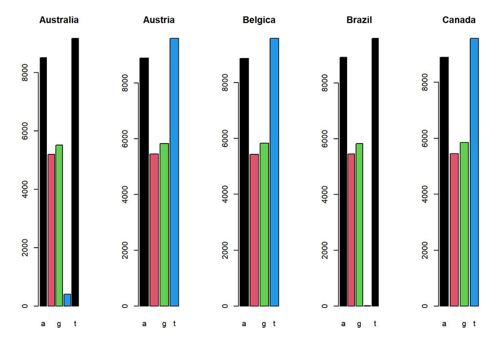

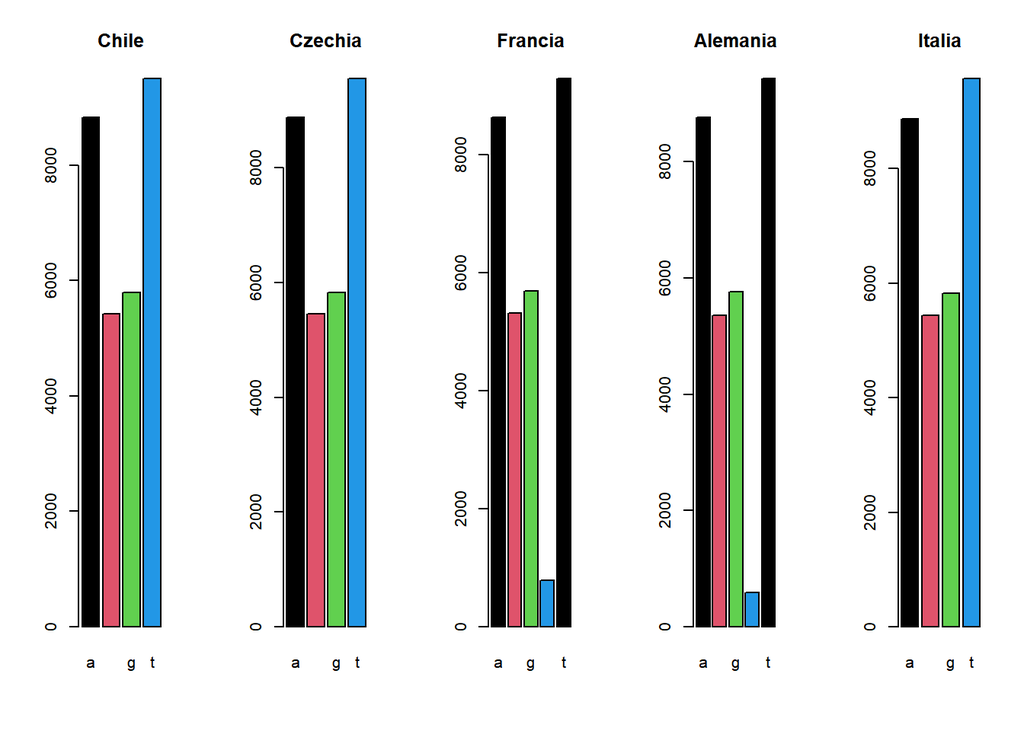

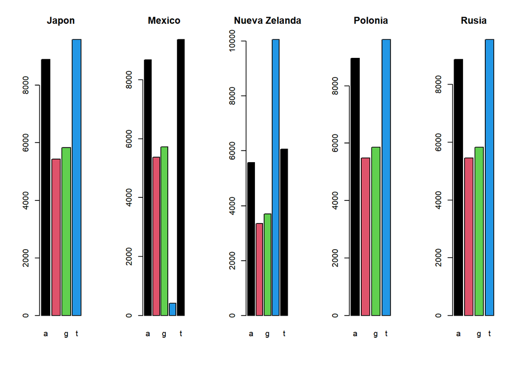

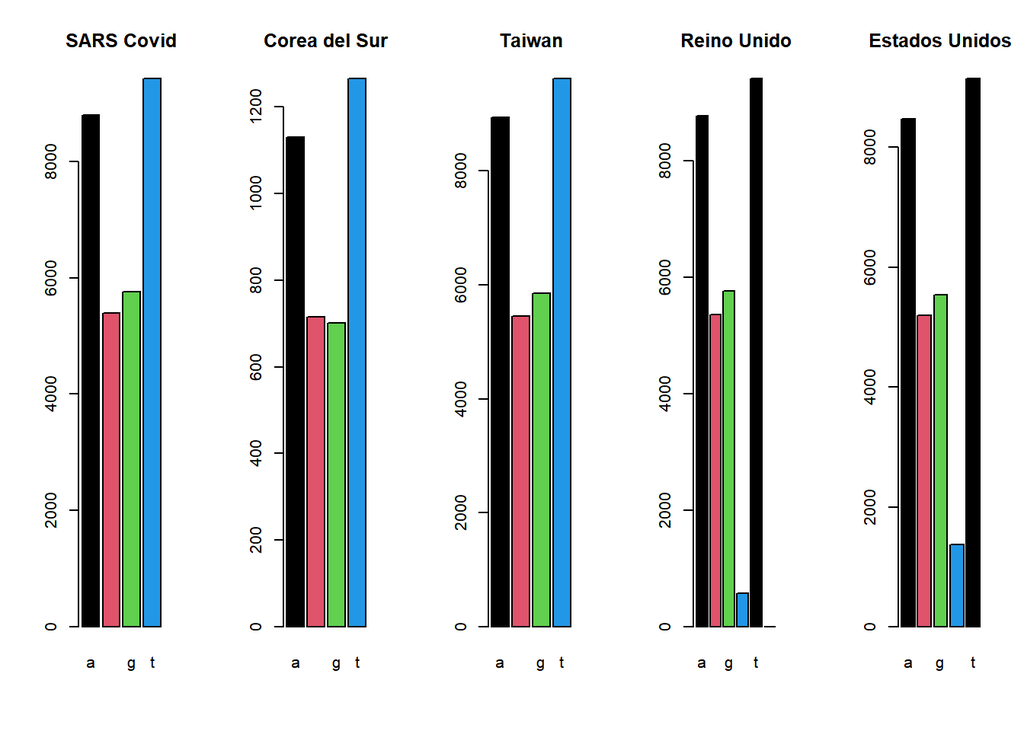

```r
Australia<-read.fasta("Australia.fasta")
Austria<-read.fasta("Austria.fasta")
Belgium<-read.fasta("Belgium.fasta")
Brazil<-read.fasta("Brazil.fasta")
canada<-read.fasta("Canada.fasta")
chile<-read.fasta("Chile.fasta")
Czechia<-read.fasta("Czechia.fasta")
Francia<-read.fasta("France.fasta")
Alemania<-read.fasta("Germany.fasta")
Italia<-read.fasta("Italy.fasta")
Japon<-read.fasta("Japan.fasta")
Mexico<-read.fasta("Mexico.fasta")
NuevaZel<-read.fasta("New_Zealand.fasta")
Polonia<-read.fasta("Poland.fasta")
Rusia<-read.fasta("Russia.fasta")
SARS<-read.fasta("SARSVirus.fasta")
CoreaSur<-read.fasta("South_Korea.fasta")
Taiwan<-read.fasta("Taiwan.fasta")
UK<-read.fasta("UK.fasta")
USA<-read.fasta("USA.fasta")


compara<-function(seq1,seq2,seq3,seq4,seq5,seq6,seq7,seq8,seq9,seq10,seq11,seq12,seq13,seq14,seq15,seq16,seq17,seq18,seq19,seq20){
  par(mfrow=c(1,5))
  barplot(table(seq1),col=1:4, main="Australia")
  barplot(table(seq2),col=1:4, main="Austria")
  barplot(table(seq3),col=1:4, main="Belgica")
  barplot(table(seq4),col=1:4, main="Brazil")
  barplot(table(seq5),col=1:4, main="Canada")
  barplot(table(seq6),col=1:4, main="Chile")
  barplot(table(seq7),col=1:4, main="Czechia")
  barplot(table(seq8),col=1:4, main="Francia")
  barplot(table(seq9),col=1:4, main="Alemania")
  barplot(table(seq10),col=1:4, main="Italia")
  barplot(table(seq11),col=1:4, main="Japon")
  barplot(table(seq12),col=1:4, main="Mexico")
  barplot(table(seq13),col=1:4, main="Nueva Zelanda")
  barplot(table(seq14),col=1:4, main="Polonia")
  barplot(table(seq15),col=1:4, main="Rusia")
  barplot(table(seq16),col=1:4, main="SARS Covid")
  barplot(table(seq17),col=1:4, main="Corea del Sur")
  barplot(table(seq18),col=1:4, main="Taiwan")
  barplot(table(seq19),col=1:4, main="Reino Unido")
  barplot(table(seq20),col=1:4, main="Estados Unidos")


}
compara(Australia,Austria,Belgium,Brazil,canada,chile,Czechia,Francia,Alemania,Italia,Japon,Mexico,NuevaZel,Polonia,Rusia,SARS,CoreaSur,Taiwan,UK,USA)
```

atributos de las secuencias, es decir su detalle descriptivo

```r
attributes(virus_sequences)
```

```
## $names
##  [1] "OP848479" "OQ520264" "OQ242023" "OQ852746" "OQ781006" "OQ690904"
##  [7] "OL752440" "OQ894089" "OX464022" "OQ748861" "BS007312" "OQ690571"
## [13] "OP729239" "OV033566" "OQ718959" "OP763667" "OF405494" "OQ194011"
## [19] "OX490409" "OQ918968"
##
## $class
## [1] "DNAbin"
##
## $description
##  [1] "OP848479.1 Severe acute respiratory syndrome coronavirus 2 isolate SARS-CoV-2/Mus musculus/AUS/P2/2022 ORF1ab polyprotein (ORF1ab) and ORF1a polyprotein (ORF1ab) genes, partial cds; surface glycoprotein (S), ORF3a protein (ORF3a), envelope protein (E), membrane glycoprotein (M), ORF6 protei…
##  [2] "OQ520264.1 Severe acute respiratory syndrome coronavirus 2 isolate SARS-CoV-2/human/AUT/Omicron-LK5/2022, complete genome"
##  [3] "OQ242023.1 Severe acute respiratory syndrome coronavirus 2 isolate SARS-CoV-2/human/BEL/HT-USAFSAM-S20831/2022 ORF1ab polyprotein (ORF1ab), ORF1a polyprotein (ORF1ab), surface glycoprotein (S), ORF3a protein (ORF3a), envelope protein (E), membrane glycoprotein (M), ORF6 protein (ORF6), ORF7…
##  [4] "OQ852746.1 Severe acute respiratory syndrome coronavirus 2 isolate SARS-CoV-2/human/BRA/LACENAL-270245412/2023 ORF1ab polyprotein (ORF1ab), ORF1a polyprotein (ORF1ab), surface glycoprotein (S), ORF3a protein (ORF3a), envelope protein (E), membrane glycoprotein (M), ORF6 protein (ORF6), ORF7…
##  [5] "OQ781006.1 Severe acute respiratory syndrome coronavirus 2 isolate SARS-CoV-2/human/CAN/UKVar1/2021 ORF1ab polyprotein (ORF1ab), ORF1a polyprotein (ORF1ab), surface glycoprotein (S), ORF3a protein (ORF3a), envelope protein (E), membrane glycoprotein (M), ORF6 protein (ORF6), ORF7a protein (…
```

[output cut: 37 more lines]

```r
names(virus_sequences)
```

```
##  [1] "OP848479" "OQ520264" "OQ242023" "OQ852746" "OQ781006" "OQ690904"
##  [7] "OL752440" "OQ894089" "OX464022" "OQ748861" "BS007312" "OQ690571"
## [13] "OP729239" "OV033566" "OQ718959" "OP763667" "OF405494" "OQ194011"
## [19] "OX490409" "OQ918968"
```

```r
attr(virus_sequences, "species")
```

```
##  [1] "Severe_acute_respiratory_syndrome_coronavirus_2"
##  [2] "Severe_acute_respiratory_syndrome_coronavirus_2"
##  [3] "Severe_acute_respiratory_syndrome_coronavirus_2"
##  [4] "Severe_acute_respiratory_syndrome_coronavirus_2"
##  [5] "Severe_acute_respiratory_syndrome_coronavirus_2"
##  [6] "Severe_acute_respiratory_syndrome_coronavirus_2"
##  [7] "Severe_acute_respiratory_syndrome_coronavirus_2"
##  [8] "Severe_acute_respiratory_syndrome_coronavirus_2"
##  [9] "Severe_acute_respiratory_syndrome_coronavirus_2"
## [10] "Severe_acute_respiratory_syndrome_coronavirus_2"
## [11] "Severe_acute_respiratory_syndrome_coronavirus_2"
## [12] "Severe_acute_respiratory_syndrome_coronavirus_2"
## [13] "Severe_acute_respiratory_syndrome_coronavirus_2"
## [14] "Severe_acute_respiratory_syndrome_coronavirus_2"
## [15] "Severe_acute_respiratory_syndrome_coronavirus_2"
## [16] "Severe_acute_respiratory_syndrome_coronavirus_2"
## [17] "Severe_acute_respiratory_syndrome_coronavirus_2"
## [18] "Severe_acute_respiratory_syndrome_coronavirus_2"
## [19] "Severe_acute_respiratory_syndrome_coronavirus_2"
## [20] "Severe_acute_respiratory_syndrome_coronavirus_2"
```

Concentraremos en un archivo todas las secuencias:

```r
write.dna(virus_sequences,  file ="virus_seqs.fasta", format = "fasta", append =
FALSE, nbcol = 6, colsep = " ", colw = 10)
```

Cargamos la secuencias:

```r
virus_seq_no_alineadas <- readDNAStringSet("virus_seqs.fasta", format = "fasta")
virus_seq_no_alineadas
```

```
## DNAStringSet object of length 20:
##      width seq                                              names
##  [1] 28811 GAGGGGCATACACTCGCTATGTC...TACGATATATAGTCTACTCTTG OP848479
##  [2] 29783 ATTAAAGGTTTATACCTTCCCAG...ATTAATTTTAGTAGTGCTATCC OQ520264
##  [3] 29683 CTTTCGATCTCTTGTAGATCTGT...TACAGTGAACAATGCTAGGGAG OQ242023
##  [4] 29832 AGGTTTATACCTTCCCAGGTAAC...AAAAAAAAAAAAAAAAAAAAAA OQ852746
##  [5] 29758 TTGTAGATCTGTTCTCTAAACGA...ATGTGTAAAATTAATTTTAGTA OQ781006
##  ...   ... ...
## [16]  3813 ATGTTTGTTTTTCTTGTTTTATT...AGTCAAATTACATTACACATAA OP763667
## [17] 29363 ATTAAAGGTTTATACCTTCCCAG...AAAAAAAAAAAAAAAAAAAAAA OF405494
## [18] 29837 TTAAAGGTTTATACCTTCCTAGG...CAAAAAAAAAAAAAAAAAAAAA OQ194011
## [19] 29885 NNNNNNNNNNNNNNNNNNNNNNN...NNNNNNNNNNNNNNNNNNNNNN OX490409
## [20] 29721 TTGTAGATCTGTTCTCTAAACGA...ATGTGTAAAATTAATTTTAGTA OQ918968
```

### Alineamiento de las secuencias

El alineamiento múltiple de secuencias es un alineamiento de más de dos secuencias. Estas secuencias, como en el caso de los alieamientos por parejas pueden ser *ADN*, *ARN* o *proteína*. Las aplicaciones más habituales de los alineamientos múltiples son:

- La reconstrucción filogenética,
- El análisis estructural de proteínas,
- La búsqueda de dominios conservados y
- La búsqueda de regiones conservadas en promotores. En todos los casos los algoritmos de alineamiento múltiple asumen que las secuencias que estamos alineando descienden de un antepasado común y lo que intentamos hacer es alinear las posiciones homólogas.

```r
virus_seq_no_alineadas <- OrientNucleotides(virus_seq_no_alineadas)
```

```
## ========================================================================================================================================================================================================
##
## Time difference of 0.25 secs
```

```r
virus_align_seqs <- AlignSeqs(virus_seq_no_alineadas)
```

```
## Determining distance matrix based on shared 11-mers:
## ================================================================================
##
## Time difference of 0.24 secs
##
## Clustering into groups by similarity:
## ================================================================================
##
## Time difference of 0.01 secs
##
## Aligning Sequences:
## ================================================================================
##
## Time difference of 4.11 secs
##
## Iteration 1 of 2:
##
## Determining distance matrix based on alignment:
## ================================================================================
##
## Time difference of 0.01 secs
##
## Reclustering into groups by similarity:
## ================================================================================
##
## Time difference of 0 secs
##
## Realigning Sequences:
## ================================================================================
##
## Time difference of 3.65 secs
##
## Iteration 2 of 2:
##
## Determining distance matrix based on alignment:
## ================================================================================
##
## Time difference of 0.01 secs
##
## Reclustering into groups by similarity:
## ================================================================================
##
## Time difference of 0 secs
##
## Realigning Sequences:
## ================================================================================
##
## Time difference of 0.01 secs
```

Visualización del resultado del alineamiento:

```r
BrowseSeqs(virus_align_seqs, highlight=0)
```

Guardar el resultado:

```r
writeXStringSet(virus_align_seqs, file = "virus_align_seq.fasta")
```

Obtener el nuevo archivo:

```r
virus_aligned <- read.alignment("virus_align_seq.fasta", format = "fasta")
virus_aligned
```

```
## $nb
## [1] 20
##
## $nam
##  [1] "OP848479" "OQ520264" "OQ242023" "OQ852746" "OQ781006" "OQ690904"
##  [7] "OL752440" "OQ894089" "OX464022" "OQ748861" "BS007312" "OQ690571"
## [13] "OP729239" "OV033566" "OQ718959" "OP763667" "OF405494" "OQ194011"
## [19] "OX490409" "OQ918968"
##
## $seq
## $seq[[1]]
## [1] "----------------------------------------------------------------------------------------------------------------------------------------------------------------------------------------------------------------------------------------------------------------------------------------------------…
##
## $seq[[2]]
## [1] "attaaaggtttataccttcccaggtaacaaaccaaccaacttttgatctcttgtagatct…---------aagctaaaagactgtgttatgtatgcatcagctgtagtgttactaatccttatgacagca…---------catacactaattctttcacacgtggtgtttattaccctgacaaagttttcagatcctcag…---------tctccctcagggtttttcggctttagaaccattggtagatttgccaataggtattaacat…---------tggggcgcgatc…
##
## $seq[[3]]
## [1] "---------------------------------------ctttcgatctcttgtagatctgttctctaaacgaactttaaaatctgtgtggctgtcact…---------aagctaaaagactgtgttatgtatgcatcagctgtagtgttactaatccttatgacagca…---------catacactaattctttcacacgtggtgtttattaccctgacaaagttttcagatcctcagttttacattcaactcaggacttgttcttacctttcttttccaatgttacttgg…
##
## $seq[[4]]
## [1] "-----aggtttataccttcccaggtaacaaaccaaccaactttcgatctcttgtagatctgttct…---------aagctaaaagactgtgttatgtatgcatcagctgtagtgttactaatccttatgacagca…---------catacactaattctttcacacgtggtgtttattaccctgacaaagttttcagatcctcag…---accaaaaaaacaacaaaagttggatggaaagtgagttcagagtttattctagtgcgaata…---------tctccctcagggt…
##
## $seq[[5]]
## [1] "--------------------------------------------------ttgtagatctgttctctaaacgaactttaaaatctgtgtggctgtcactcggctgcatgc…---------aagctaaaagactgtgttatgtatgcatcagctgtagtgttactaatccttatgacagca…------ctctgggaccaatggtactaagaggtttgataaccctgtcctaccatttaatgatggtgt…---accacaaaaacaacaaaagttggatggaaagtgagttcaga…
##
## $seq[[6]]
## [1] "---------------------------------------------------------------------------------------------------------------------------------------------------------------------------------------------------------tcgtccgtgttgcagccgatcatcagcacatctaggttttgtccgggtgtgaccgaaagg…---------tctccctcagggtttttcggc…
##
## $seq[[7]]
## [1] "------------------------------------------------------agatctgttctctaaacgaactttaaaatctgtgtggctgtcactcggctgcatgcttag…---------aagctaaaagactgtgttatgtatgcatcagctgtagtgttactaatccttatgacagca…------ctctgggaccaatggtactaagaggtttgataaccctgtcctaccatttaatgatggtgt…---accacaaaaacaacaaaagttggatggaaagtgagtt…
##
## $seq[[8]]
## [1] "----------------------------------------------------------------------------------------------------ggctgcatgcttagtgcactcacgcagtataattaataactaattactgtcgttgacagg…---tagtgcgtgagccagaagatctccctcagggtttttcggctttagaaccattggtagatt…------atctaaacgaacaaactaaa-tgtctgataatggaccccaaaatcagcgaaatgcaccccg…
##
## $seq[[9]]
## [1] "nnnnnnnnnnnnnnnnnnnnnnnnnnnnnnnnnnnnnnnnnnnnnnnnnnnnnnagatct…---ggtgagtttattctagtgcgaataattgcacttttgaatatgtctctcagccttttcttatggaccttgaaggaaaacagggtaatttcaaaaatcttagggaatttgtgtttaagaatattgatggttattttaaaatatattctaagcacacgcctattaatttagtgcgtga---------tctccctcagggtttttcggctttagaaccattggtagatttgc…
##
## $seq[[10]]
## [1] "---------------------------------------ctttcgatctcttgtagatctgttctctaaacgaactttaaaatctgtgtggctgtcact…---------aagctaaaagactgtgttatgtatgcatcagctgtagtgttactaatccttatgacagca…---------catacactaattctttcacacgtggtgtttattaccctgacaaagttttcagatcctcag…---accaaaaaaacaacaaaagttggatggaaagtgagttcagagtttattc…
##
```

[output cut: 21 more lines]

```
## $seq[[18]]
## [1] "-ttaaaggtttataccttcctaggtaacaaaccaaccaacttttgatctcttgtagatctg…---------aagctaaaagactgtgttatgtatgcatcagctgtagtgttactaatccttatgacagca…---------catacactaattctttcacacgtggtgtttattaccctgacaaagttttcagatcctcag…---------tctccctcagggtttttcggctttagaaccattggtagatttgccaataggtattaacat…---------tggggcgcgat…
##
## $seq[[19]]
## [1] "nnnnnnnnnnnnnnnnnnnnnnnnnnnnnnnnnnnnnnnnnnnnnnnnnnnnnnagatct…---------aagctaaaagactgtgttatgtatgcatcagctgtagtgttactaatccttatgacagca…------ctctgggaccaatggtactaagaggtttgataaccctgtcctaccatttaatgatggtgt…--nttaccacaaaaacaacaaaagttggatggaaagtgagttcagagtttattctagtgcga…---------tctccctcagggtttttcggct…
##
## $seq[[20]]
## [1] "--------------------------------------------------ttgtagatctgttctctaaacgaactttaaaatctgtgtggctgtcactcggctgcatgc…---------aagctaaaagactgtgttatgtatgcatcagctgtagtgttactaatccttatgacagca…---------catacactaattctttcacacgtggtgtttattaccctgacaaagttttcagatcctcag…---accaaaaaaacaacaaaagttggatggaaagtgagttc…
##
##
## $com
## [1] NA
##
## attr(,"class")
## [1] "alignment"
```

Creación de una matriz de distancia:

```r
matriz_distancia <- dist.alignment(virus_aligned, matrix = "similarity")
```

Visualización la matriz de distancia: donde sombras más oscuras de gris significan una mayor distancia

```r
temp <- as.data.frame(as.matrix(matriz_distancia))
temp
```

```
##            OP848479   OQ520264   OQ242023   OQ852746   OQ781006   OQ690904
## OP848479 0.00000000 0.04786599 0.05142175 0.05473974 0.03084544 0.02220382
## OQ520264 0.04786599 0.00000000 0.03530587 0.03800217 0.05379831 0.05041768
## OQ242023 0.05142175 0.03530587 0.00000000 0.04607213 0.05658713 0.05367917
## OQ852746 0.05473974 0.03800217 0.04607213 0.00000000 0.06000830 0.05704399
## OQ781006 0.03084544 0.05379831 0.05658713 0.06000830 0.00000000 0.03634685
## OQ690904 0.02220382 0.05041768 0.05367917 0.05704399 0.03634685 0.00000000
## OL752440 0.03084544 0.05445786 0.05747754 0.06088574 0.01923950 0.03680989
## OQ894089 0.04543972 0.05232153 0.05524735 0.05737579 0.05195513 0.04899065
## OX464022 0.04141577 0.05876417 0.06105338 0.06378928 0.04958678 0.04423740
## OQ748861 0.05632673 0.03761394 0.04533493 0.02722297 0.06116702 0.05851065
## BS007312 0.05244011 0.03668706 0.03579126 0.04675521 0.05743689 0.05461824
## OQ690571 0.02605918 0.05145125 0.05532104 0.05775091 0.03798882 0.03209593
## OP729239 0.04608787 0.02194991 0.03104187 0.03730768 0.05069115 0.04859035
## OV033566 0.02446742 0.05215048 0.05475718 0.05819686 0.03666301 0.03023268
## OQ718959 0.02653865 0.05161974 0.05417587 0.05836936 0.03761647 0.03186804
## OP763667 0.08720414 0.06493130 0.07259540 0.08434823 0.09027356 0.09171803
## OF405494 0.01694641 0.04996323 0.05272000 0.05635709 0.03309404 0.02626129
## OQ194011 0.04749636 0.02089271 0.03482550 0.03752996 0.05316907 0.05008043
## OX490409 0.03051172 0.05357173 0.05642167 0.05932387 0.01752589 0.03567557
## OQ918968 0.05477428 0.03563295 0.04408395 0.02519630 0.06027993 0.05749442
##            OL752440   OQ894089   OX464022   OQ748861   BS007312   OQ690571
## OP848479 0.03084544 0.04543972 0.04141577 0.05632673 0.05244011 0.02605918
## OQ520264 0.05445786 0.05232153 0.05876417 0.03761394 0.03668706 0.05145125
## OQ242023 0.05747754 0.05524735 0.06105338 0.04533493 0.03579126 0.05532104
## OQ852746 0.06088574 0.05737579 0.06378928 0.02722297 0.04675521 0.05775091
## OQ781006 0.01923950 0.05195513 0.04958678 0.06116702 0.05743689 0.03798882
## OQ690904 0.03680989 0.04899065 0.04423740 0.05851065 0.05461824 0.03209593
## OL752440 0.00000000 0.05295584 0.04992994 0.06199227 0.05834575 0.03843840
## OQ894089 0.05295584 0.00000000 0.04148626 0.05799771 0.05585130 0.04935073
## OX464022 0.04992994 0.04148626 0.00000000 0.06537763 0.06189209 0.04494744
## OQ748861 0.06199227 0.05799771 0.06537763 0.00000000 0.04571966 0.05951022
## BS007312 0.05834575 0.05585130 0.06189209 0.04571966 0.00000000 0.05685377
## OQ690571 0.03843840 0.04935073 0.04494744 0.05951022 0.05685377 0.00000000
## OP729239 0.05276103 0.04864976 0.05853937 0.03871601 0.03801837 0.05161731
## OV033566 0.03668829 0.05024928 0.04525165 0.05947286 0.05562184 0.03314854
## OQ718959 0.03806165 0.04243514 0.03602027 0.05951397 0.05510202 0.03155647
## OP763667 0.09027356 0.03851285 0.09457809 0.08434823 0.07259540 0.09027356
## OF405494 0.03259572 0.04560250 0.04085250 0.05768945 0.05331752 0.02578282
## OQ194011 0.05414756 0.05165499 0.05847253 0.03716346 0.03574730 0.05111606
```

[output cut: 29 more lines]

```
## OQ690904 0.03567557 0.05749442
## OL752440 0.01848558 0.06119576
## OQ894089 0.05201857 0.05716620
## OX464022 0.04862250 0.06506059
## OQ748861 0.06108472 0.02058940
## BS007312 0.05727451 0.04445307
## OQ690571 0.03736328 0.05854591
## OP729239 0.05079595 0.03660340
## OV033566 0.03552800 0.05818836
## OQ718959 0.03699140 0.05856919
## OP763667 0.08994785 0.08485412
## OF405494 0.03229000 0.05648078
## OQ194011 0.05293013 0.03462900
## OX490409 0.00000000 0.06015625
## OQ918968 0.06015625 0.00000000
```

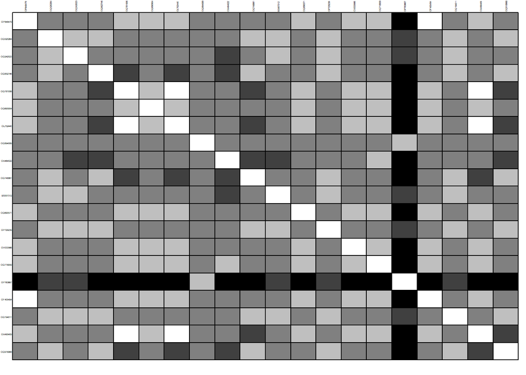

```r
table.paint(temp, cleg=0, clabel.row=.20, clabel.col=.20) + scale_color_viridis()
```

Creación del árbol con el paquete ape:

```r
virus_filogenetico <- nj(matriz_distancia)
class(virus_filogenetico)
```

```
## [1] "phylo"
```

Gráfica del árbol:

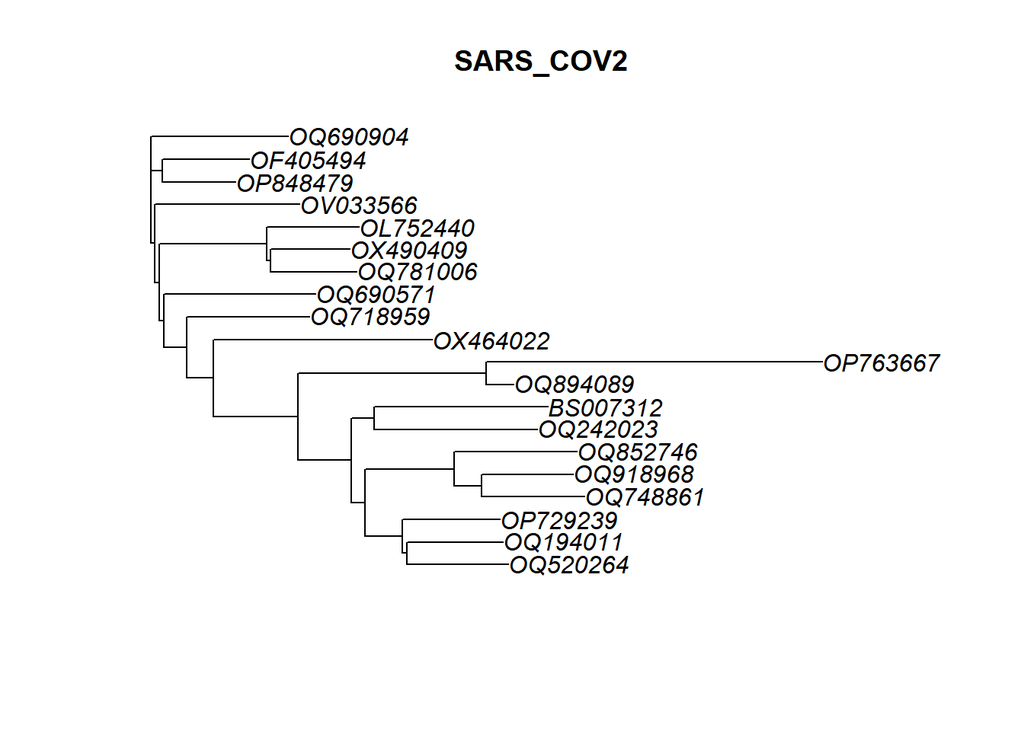

```r
virus_plot_filogenetico <- ladderize(virus_filogenetico)
plot(virus_plot_filogenetico)
title("SARS_COV2")
```

Gráfica utilizando ggtree que es parte de ggplot:

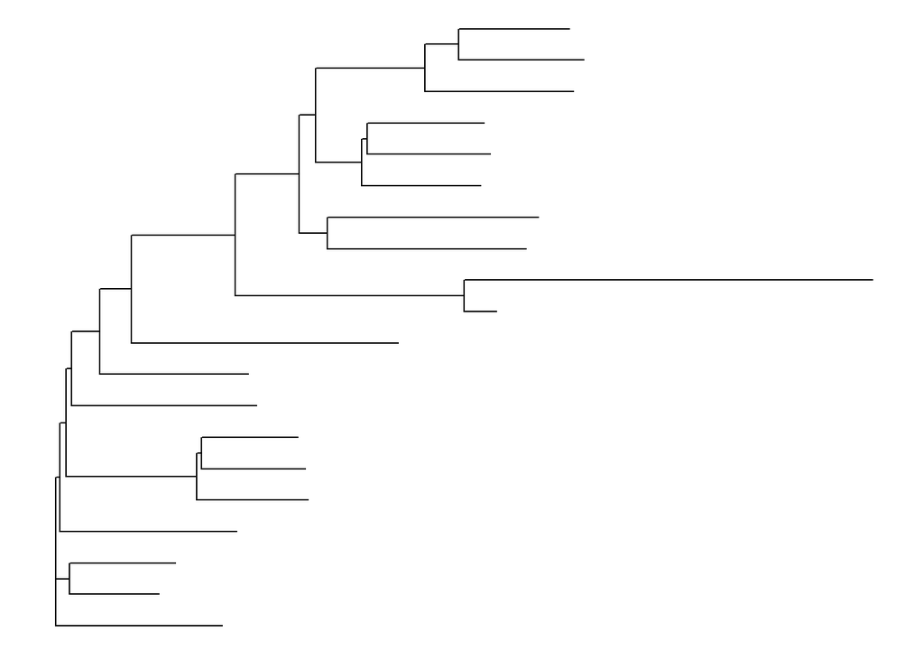

```r
ggtree(virus_plot_filogenetico)
```

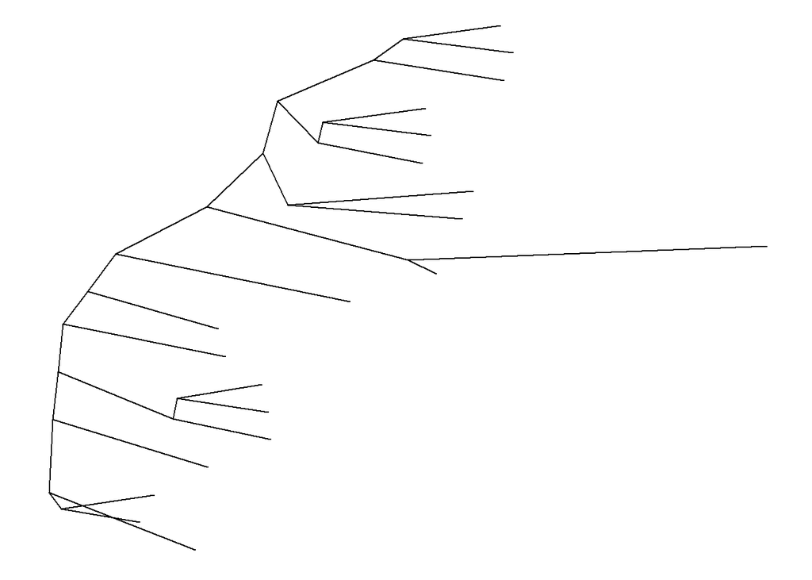

```r
ggtree(virus_plot_filogenetico, layout="slanted")
```

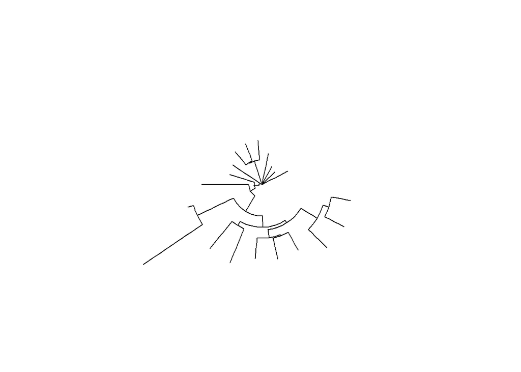

```r
ggtree(virus_plot_filogenetico, layout="circular")
```

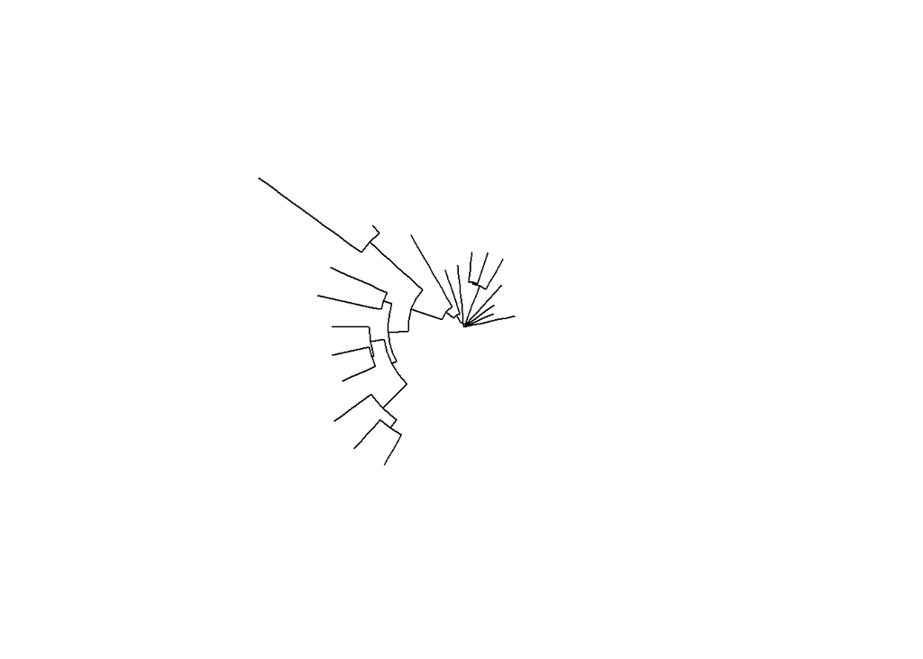

```r
ggtree(virus_plot_filogenetico, layout="fan", open.angle=120)
```

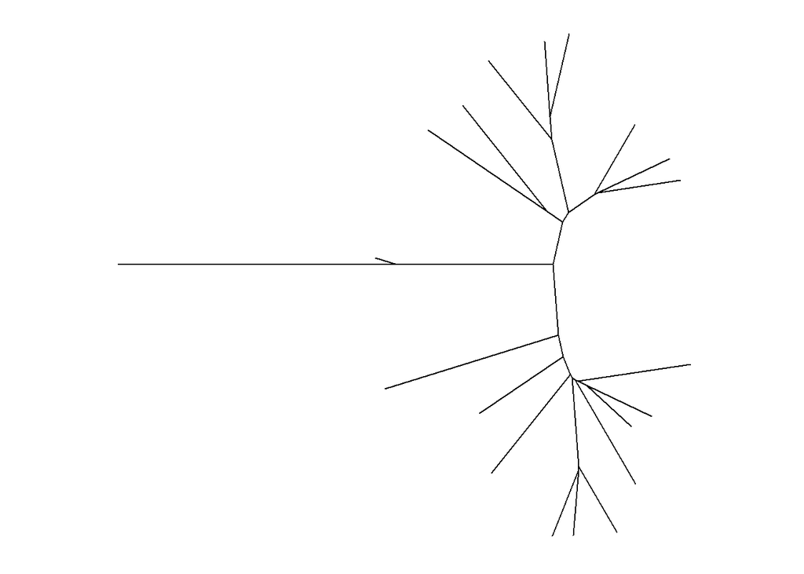

```r
ggtree(virus_plot_filogenetico, layout="equal_angle")
```

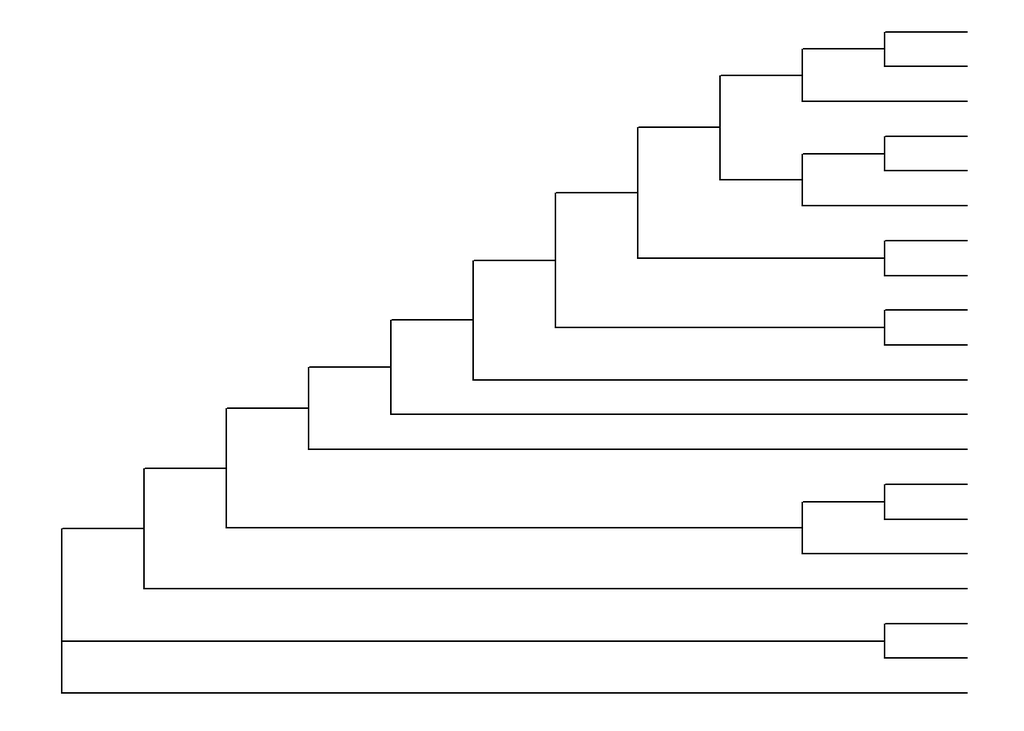

```r
ggtree(virus_plot_filogenetico, branch.length='none')
```

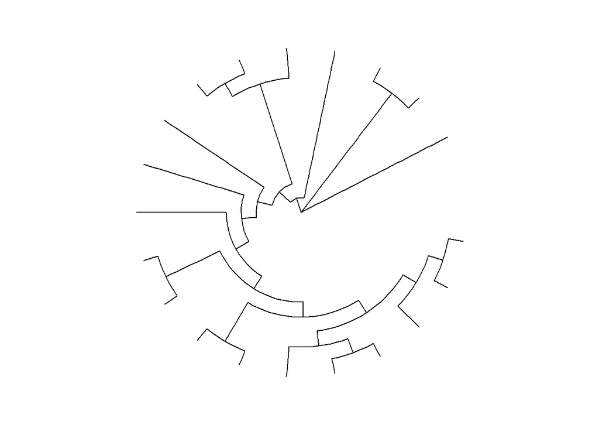

```r
ggtree(virus_plot_filogenetico, branch.length='none', layout='circular')
```

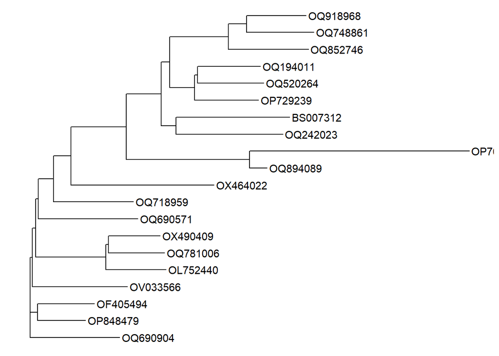

```r
ggtree(virus_plot_filogenetico ) + geom_tiplab()
```

Visualización el alineamiento de las secuencias:

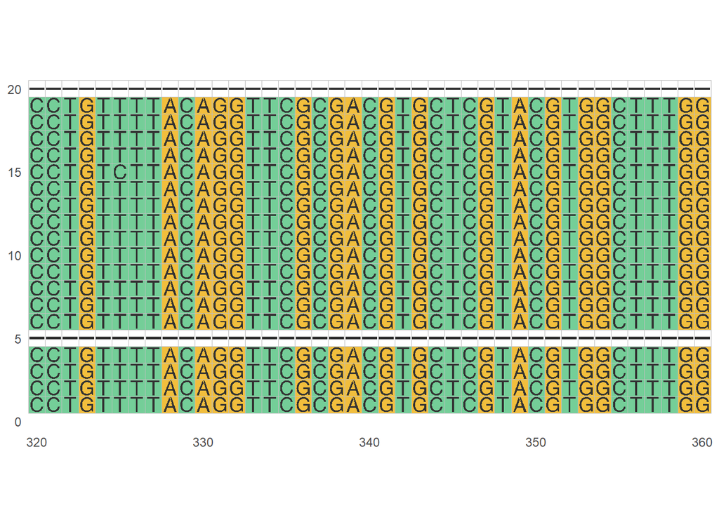

```r
library(ggmsa)
ggmsa(virus_align_seqs, 320, 360, color = "Chemistry_AA")
```

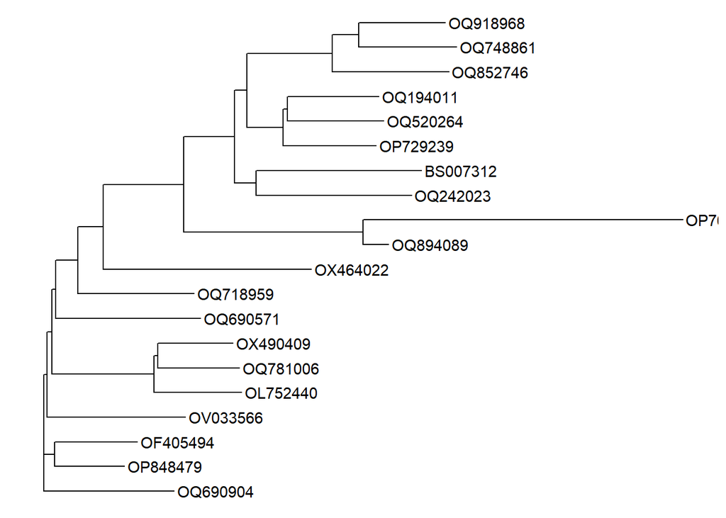

```r
plot_virus <- ggtree(virus_plot_filogenetico) + geom_tiplab()
plot_virus
```

```r
citation("dplyr")
```

```
##
##   Wickham H, François R, Henry L, Müller K, Vaughan D (2023). _dplyr: A
##   Grammar of Data Manipulation_. R package version 1.1.2,
##   <https://CRAN.R-project.org/package=dplyr>.
##
## A BibTeX entry for LaTeX users is
##
##   @Manual{,
##     title = {dplyr: A Grammar of Data Manipulation},
##     author = {Hadley Wickham and Romain François and Lionel Henry and Kirill Müller and Davis Vaughan},
##     year = {2023},
##     note = {R package version 1.1.2},
##     url = {https://CRAN.R-project.org/package=dplyr},
##   }
```

```r
citation("ggplot2")
```

```
##
##   H. Wickham. ggplot2: Elegant Graphics for Data Analysis.
##   Springer-Verlag New York, 2016.
##
## A BibTeX entry for LaTeX users is
##
##   @Book{,
##     author = {Hadley Wickham},
##     title = {ggplot2: Elegant Graphics for Data Analysis},
##     publisher = {Springer-Verlag New York},
##     year = {2016},
##     isbn = {978-3-319-24277-4},
##     url = {https://ggplot2.tidyverse.org},
##   }
```

## Referencias

*NCBI Virus*. (n.d.). https://www.ncbi.nlm.nih.gov/labs/virus/vssi/#/virus?SeqType_s=Nucleotide&VirusLineage_ss=Severe%20acute%20respiratory%20syndrome%20coronavirus%202,%20taxid:2697049&utm_source=nuccore&utm_medium=referral